# Type charts

By **Franklin Oliveira**

This notebook contains all code necessary to make the "type" charts from `crustacea` database. Here you'll find some basic data treatment and charts' code.

Database: 'Planilha geral Atualizda FINAL com correções.xlsx'.

```python
import datetime
import numpy as np
import pandas as pd

from collections import defaultdict

# quick visualization
import seaborn as sns
import matplotlib.pyplot as plt

# Waffle Charts
from pywaffle import Waffle
# docs: https://pywaffle.readthedocs.io/en/latest/examples/block_shape_distance_location_and_direction.html

# visualization
import altair as alt

# enabling notebook renderer
alt.renderers.enable('notebook')

# disabling rows limit
alt.data_transformers.disable_max_rows()
```

```
DataTransformerRegistry.enable('default')
```

## Importing data...

```python
excel = pd.ExcelFile('Planilha geral Atualizda FINAL com correções.xlsx')
sheet_name = excel.sheet_names

print('The excel file contains the following sheets:', sheet_name)
print('\nDatabase is in sheet:', sheet_name[0])
```

```
The excel file contains the following sheets: ['Banco de Dados Colecao Carcinol', 'Planilha1']

Database is in sheet: Banco de Dados Colecao Carcinol
```

```python
# db = excel.parse(sheet_name[0], sep=';', encoding='utf-8-sig')
db = pd.read_csv('db.csv', sep=',', encoding='utf-8-sig', low_memory=False)  # db pre-treated by Asla
print(f'The database has {db.shape[0]} rows and {db.shape[1]} columns.')
```

```
The database has 28689 rows and 132 columns.
```

```python
# copying database to another variable to make a few changes keeping the original intact
crustaceas = db.copy()
```

### Name columns

`Determiner First Name1` e `Determiner Last Name1`

#### treating determiner's name

In this step, we're going to put together determiner's first and last name.

`Determiner First Name1` + `Determiner Last Name1`

Just concatenating those two columns is not satisfactory because there's some dirt in these data columns. So, let's begin by treating them...

```python
def treat_names(name, pos='first'):
    '''
    Treat names keeping NaN as such.

    Arguments:
        - name: name to be treated.
        - pos (str): name position. One of ['first', 'last']
    '''
    if type(name) == str and pos == 'first':     # primeiro nome

        if len(name.split(' ')) > 1:             # trata se o nome é composto (+ de um nome)
            return str(name).strip().split(' ')[0].capitalize()
        else:
            return str(name).strip().capitalize()

    elif type(name) == str and pos == 'last':    # último sobrenome

        if len(name.split(' ')) > 1:             # trata se o último nome é composto (+ de um sobrenome)
            return str(name).strip().split(' ')[-1].capitalize()
        else:
            return str(name).strip().capitalize()
    else:
        return name
```

applying function to the two column names

```python
crustaceas['Determiner First Name1'] = crustaceas['Determiner First Name1'].apply(treat_names)
# crustaceas['Determiner First Name1'].value_counts()
```

```python
crustaceas['Determiner Last Name1'] = crustaceas['Determiner Last Name1'].apply(lambda x:
                                                                treat_names(x, pos='last'))
# crustaceas['Determiner Last Name1'].value_counts()
```

```python
# creating column with First and Last name for identification
crustaceas['Determiner First_and_Last Name'] = crustaceas['Determiner First Name1'] + ' ' + crustaceas['Determiner Last Name1']
```

## Adjusting columns names

### removing '\n'

```python
crustaceas.columns = [str(col).replace(r'\n','') for col in crustaceas.columns]
```

## preparing data for charts...

### Column: `Type Status1`

```python
crustaceas['Type Status1'].value_counts().head()
```

```
Paratipo    433
Holotipo    203
ParaTIPO    142
PARATIPO    120
HOLOTIPO     82
Name: Type Status1, dtype: int64
```

#### Let's begin cleaning this data and lowering all cases.

```python
crustaceas['Type Status1'] = crustaceas['Type Status1'].str.strip().str.lower().str.capitalize()
```

```python
crustaceas['Type Status1'].value_counts().head()
```

```
Paratipo         695
Holotipo         285
Alotipo           81
Topotipo           9
Paralectotipo      6
Name: Type Status1, dtype: int64
```

### preparing taxonomy columns

`Kingdom` - `Phylum1` - `Subphylum1` - `Class1` - `Subclass1` - `Infraclass1` - `Superorder1` - `Order1` - `Suborder1` - `Infraorder1` - `Superfamily1` - `Family1` - `Subfamily1` - `Tribe1` - `Genus1` - `Species1`

```python
taxon_columns = crustaceas.columns[21:37]  # selecting taxonomy columns

# defining function
def treat_str(x):
    return str(x).lower().capitalize().strip()

# applying treatment
for col in taxon_columns:
    print(f'Adjusting column {col}')
    crustaceas[col] = crustaceas[col].apply(treat_str)
```

```
Adjusting column Kingdom
Adjusting column Phylum1
Adjusting column Subphylum1
Adjusting column Class1
Adjusting column Subclass1
Adjusting column Infraclass1
Adjusting column Superorder1
Adjusting column Order1
Adjusting column Suborder1
Adjusting column Infraorder1
Adjusting column Superfamily1
Adjusting column Family1
Adjusting column Subfamily1
Adjusting column Tribe1
Adjusting column Genus1
Adjusting column Species1
```

### adding `Genus1` and `Species1`together (they completely identify each animal's species)

```python
crustaceas['genus_and_species'] = crustaceas['Genus1'] + ' ' + crustaceas['Species1']
crustaceas['genus_and_species'] = crustaceas['genus_and_species'].str.lower().str.capitalize()
```

### Collecting date (year) and sclicing main DB to a smaller dataset

Columns: `Determined Date1` - `Class1` - `Kingdom` and more...

```python
# slicing main database (crustaceas)
Table = crustaceas[['Cataloged Date','Determined Date1','Start Date','Class1','Kingdom',
                    'Genus1', 'Species1', 'Type Status1',
                   'Determiner First_and_Last Name', 'Determiner First Name1',
                   'Determiner Last Name1', 'genus_and_species','Min Depth', 'Max Depth', 'Count 1',
                   'Species Author1', 'Order1', 'Suborder1', 'Infraorder1',
                   'Superfamily1', 'Family1', 'Subfamily1', 'Tribe1']].copy()

# p.s.: Determined Date1 has many missing values... CHECK THAT
d = []
counter=0
for row in Table['Cataloged Date']:
    if not str(row).find('/')==-1:
        dates_values = str(row).split("/")
        year = int(dates_values[0])
        month = int(dates_values[1])
        if (month>1) and (month<12):
            #store the year and month in a datetime datatype for later sorting
            dateRecord = datetime.datetime(year,month,1)

    d.append({'cataloged_year':year, 'count':Table.loc[counter,'Count 1'],
              'class':Table.loc[counter,'Class1'],
              'kingdom':Table.loc[counter,'Kingdom'], 'genus':Table.loc[counter,'Genus1'],
              'species':Table.loc[counter,'Species1'],
              'genus_and_species': Table.loc[counter,'genus_and_species'],
              'type_status':Table.loc[counter,'Type Status1'],
              'determiner_first_and_last_name':Table.loc[counter,'Determiner First_and_Last Name'],
              'determiner_first_name':Table.loc[counter,'Determiner First Name1'],
              'determiner_last_name':Table.loc[counter,'Determiner Last Name1'],
              'min_depth':Table.loc[counter,'Min Depth'],
              'max_depth':Table.loc[counter,'Max Depth'],
              'species_author':Table.loc[counter,'Species Author1'],
              'order':Table.loc[counter,'Order1'],
              'suborder':Table.loc[counter,'Suborder1'],
              'infraorder':Table.loc[counter, 'Infraorder1'],
              'superfamily':Table.loc[counter,'Superfamily1'],
              'family':Table.loc[counter,'Family1'],
              'subfamily':Table.loc[counter,'Subfamily1'],
              'tribe':Table.loc[counter,'Tribe1']
             })
    counter = counter+1

NewTable = pd.DataFrame(d)


### collecting determined year (p.s.: being careful to keep NaNs as they show up)
NewTable['determined_year'] = np.nan

d1 = []
counter=0
for row in Table['Determined Date1']:
    try:  # if Determined Date1 is empty, keep it so
        if np.isnan(row):
            year= np.NAN

    except:
        if not str(row).find('/')==-1:
            dates_values = str(row).split("/")
            year = int(dates_values[0])
            month = int(dates_values[1])
            if (month>1) and (month<12):
                #store the year and month in a datetime datatype for later sorting
                dateRecord = datetime.datetime(year,month,1)

    NewTable.loc[counter, 'determined_year'] = year
    counter = counter+1


### collecting start year (p.s.: being careful to keep NaNs as they show up)
NewTable['start_year'] = np.nan
d1 = []
counter=0
for row in Table['Start Date']:
    try:  # if Start Date is empty, keep it so
        if np.isnan(row):
            year= np.NAN

    except:
        if not str(row).find('/')==-1:
            dates_values = str(row).split("/")
            year = int(dates_values[0])
            month = int(dates_values[1])
            if (month>1) and (month<12):
                #store the year and month in a datetime datatype for later sorting
                dateRecord = datetime.datetime(year,month,1)

    NewTable.loc[counter, 'start_year'] = year
    counter = counter+1

# NewTable['determined_year'] = pd.Series(year, index=NewTable.index)
NewTable.head(2)
```

|  | cataloged_year | count | class | kingdom | genus | species | genus_and_species | type_status | determiner_first_and_last_name | determiner_first_name | ... | species_author | order | suborder | infraorder | superfamily | family | subfamily | tribe | determined_year | start_year |
| --- | --- | --- | --- | --- | --- | --- | --- | --- | --- | --- | --- | --- | --- | --- | --- | --- | --- | --- | --- | --- | --- |
| 0 | 1980 | 5 | Malacostraca | Animalia | Penaeus | Schmitti | Penaeus schmitti | NaN | Alceu Castro | Alceu | ... | Burkenroad, 1936 | Decapoda | Nan | Nan | Nan | Penaeidae | Nan | Penaeini | NaN | 1969.0 |
| 1 | 1980 | 15 | Malacostraca | Animalia | Penaeus | Schmitti | Penaeus schmitti | NaN | Alceu Castro | Alceu | ... | Burkenroad, 1936 | Decapoda | Nan | Nan | Nan | Penaeidae | Nan | Penaeini | NaN | NaN |

2 rows × 23 columns

```python
# checks if NaNs are in the same position
result = (NewTable['start_year'].isna() == crustaceas['Start Date'].isna()).sum() == NewTable.shape[0]

if result:
    print('Start year info is valid.')
else:
    print("There's something wrong with NewTable. Check how you're collecting Start Year info.")
```

```
Start year info is valid.
```

```python
# year in which the holotipo was "firstly" found
NewTable['holotipo_year'] = NewTable['species_author'].str.extract('(\d+)')
```

### creating `years` columns in crustaceas

```python
def catch_year(row):
    if not str(row).find('/')==-1:
        dates_values = str(row).split("/")
        year = int(dates_values[0])
        month = int(dates_values[1])
        return year
    else:
        return np.NaN
```

```python
crustaceas['determined_year'] = crustaceas['Determined Date1'].apply(catch_year)
crustaceas['start_year'] = crustaceas['Start Date'].apply(catch_year)
crustaceas['cataloged_year'] = crustaceas['Cataloged Date'].apply(catch_year)
crustaceas['holotipo_year'] = crustaceas['Species Author1'].str.extract('(\d+)')
```

## Graph

### Depth

First, let's make some adjustments to prepare all the data we need for this chart.

#### adjusting columns `determined_year`, `cataloged_year` and `start_year` to `*int*` format

```python
def str_with_nan2int(string):
    if not np.isnan(string):
        return int(string)
    else:
        return np.NAN
```

```python
NewTable['determined_year'] = NewTable['determined_year'].apply(str_with_nan2int) #has NaN
# NewTable['determined_year'] = NewTable['determined_year'].astype(int)
NewTable['cataloged_year'] = NewTable['cataloged_year'].astype(int)
NewTable['start_year'] = NewTable['start_year'].apply(str_with_nan2int) #has NaN
```

#### removing duplicated rows as we took a subset of the main database

```python
teste1 = NewTable.drop_duplicates().copy()  # removes duplicated rows (with same values in ALL columns)
print('Duplicated registers:',NewTable.shape[0] - NewTable.drop_duplicates().shape[0])
# teste1.head(2)
```

```
Duplicated registers: 7001
```

### Creating chart: number of cataloged animals per depth

#### defining some parameters

```python
colors = ['#d62728', '#f58518', '#d95f02',
          '#d62729', '#f58519', '#d95f03',
          '#4daf4a', '#8c6d31',
          '#79706e', '#bab0ac', '#d8b5a5'
         ]

types = ['Holotipo', 'Alotipo', 'Neotipo',
          'Sintipo', 'Lectotipo', 'Paralectotipo',
          'Paratipo', 'Topotipo',
          'Tipo', 'Co-tipo', 'Material tipo'
        ]

opacities= [1, 1, 1,
           0.4,0.4,0.4,
           1,1,1,
           1,1,1]

# creating dictionary with type:color
type_color = defaultdict()
for t in range(len(types)):
    type_color[types[t]] = colors[t]
```

### separating and grouping types

```python
# different orders
orders = teste1['order'].unique()

# types
types = teste1['type_status'].unique()

group_types = []
for t in types:
    if t not in ['Holotipo', 'Alotipo', 'Paratipo']:
        group_types.append(t)

group_types = [i for i in group_types if 'nan' not in str(i)]  # removing nan
```

### Graph

```python
# counting catalog. per year, type and depth
t = teste1.groupby(['start_year','type_status','min_depth', 'count']).count()['class'].reset_index()
t.rename(columns={'class':'reg_counts'}, inplace=True)
t['type_status'].isna().sum()  # nenhum NaN
```

```
0
```

### Types per depth

```python
t = teste1[~teste1['type_status'].isna()].copy()
t = t.groupby(['start_year', 'min_depth']).count()['count'].reset_index()
```

```python
# defining range of y axis
l = []
for depth in t['min_depth']:
    try:
        l.append(float(depth))
    except:
        pass

max_y = max(l)
min_y = min(l)
```

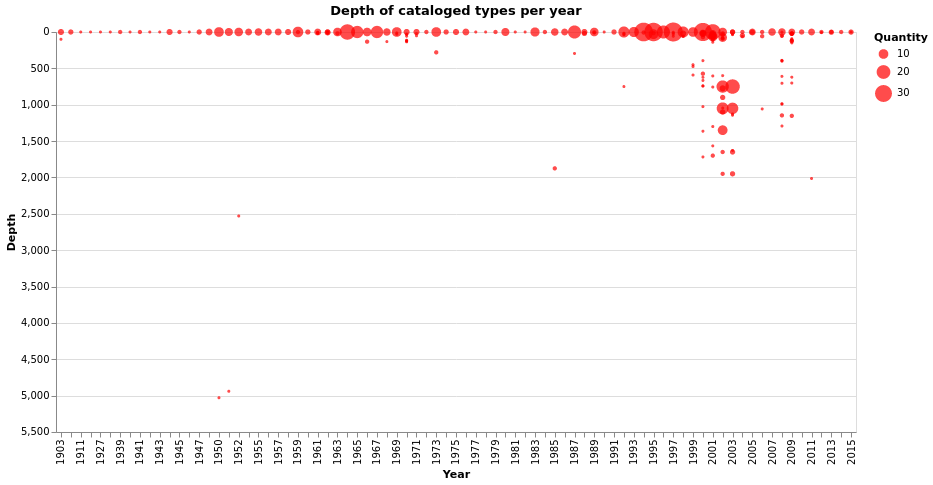

```python
# p.s.: I'm not considering the non-types
g1 = alt.Chart(t, title='Depth of cataloged types per year',
              height=400, width=800).mark_circle(color='red').encode(
    x= alt.X('start_year', type='ordinal', title='Year'),
    y= alt.Y('min_depth', type='quantitative', title='Depth', scale=alt.Scale(domain=[max_y,min_y])),
    size=alt.Size('count',type= 'quantitative', legend=alt.Legend(title='Quantity'))
)

# salvando o gráfico
# g1.save('./depth/types_per_year.svg')
# g1.save('./depth/types_per_year.png')
# g1.save('./depth/types_per_year.html')

g1
```

### Non-types per depth

```python
t = teste1[teste1['type_status'].isna()].copy()
t = t.groupby(['start_year', 'min_depth']).count()['count'].reset_index()
```

**p.s.:** temporary adjustment!!!!

removed "strange" years: 27 e 2099

```python
t = t[(t['start_year'] > 1800) & (t['start_year'] <= 2020)]
```

```python
t['start_year'].value_counts()
```

```
2009.0    237
2008.0    181
2003.0     70
2002.0     68
2000.0     57
         ...
1919.0      1
1954.0      1
1925.0      1
1959.0      1
1880.0      1
Name: start_year, Length: 113, dtype: int64
```

```python
# defining range of y axis
l = []
for depth in t['min_depth']:
    try:
        l.append(float(depth))
    except:
        pass

max_y = max(l)
min_y = min(l)
```

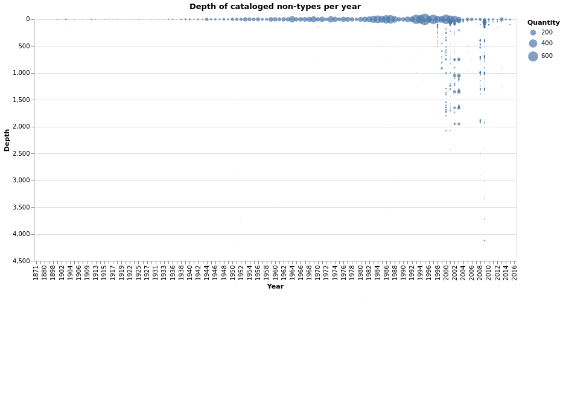

```python
# p.s.: I'm not considering the non-types
g2 = alt.Chart(t, title='Depth of cataloged non-types per year',
              height=400, width=800).mark_circle().encode(
    x= alt.X('start_year', type='ordinal', title='Year'),
    y= alt.Y('min_depth', type='quantitative', title='Depth', scale=alt.Scale(domain=[4500,min_y])), # limits
    size=alt.Size('count',type= 'quantitative', legend=alt.Legend(title='Quantity'))
)

# saving chart
g2.save('./depth/non-types_per_year.svg')
g2.save('./depth/non-types_per_year.png')
g2.save('./depth/non-types_per_year.html')

g2
```

### Filtering by type

```python
# translation to graph title
types_translate = {
    'Holotipo':'holotypes',
    'Alotipo':'alotypes',
    'Paratipo':'paratypes'
}
```

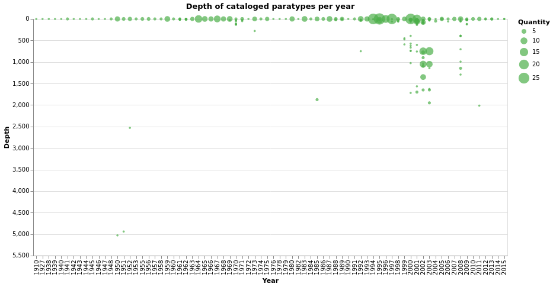

```python
for tp in ['Holotipo', 'Alotipo', 'Paratipo']:
    temp = teste1[teste1['type_status'] == tp]
    t = temp.groupby(['start_year', 'min_depth']).count()['count'].reset_index()

    # defining range of y axis
    l = []
    for depth in t['min_depth']:
        try:
            l.append(float(depth))
        except:
            pass

    max_y = max(l)
    min_y = min(l)

    # making chart
    g3 = alt.Chart(t, title=f'Depth of cataloged {types_translate[tp]} per year',
                   height=400, width=800
                  ).mark_circle(color= f'{type_color[tp]}').encode(
        x= alt.X('start_year', type='ordinal', title='Year'),
        y= alt.Y('min_depth', type='quantitative', title='Depth', scale=alt.Scale(domain=[max_y,min_y])),
        size=alt.Size('count',type= 'quantitative', legend=alt.Legend(title='Quantity'))
    )

    # saving chart
#     g3.save(f'./depth/{tp}_per_year.svg')
#     g3.save(f'./depth/{tp}_per_year.png')
#     g3.save(f'./depth/{tp}_per_year.html')

g3
```

#### depth of other types

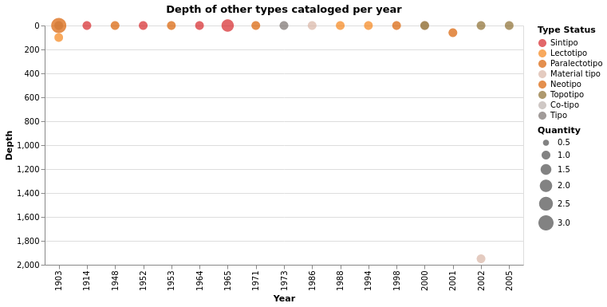

```python
temp = teste1[teste1['type_status'].isin(group_types)]
t = temp.groupby(['start_year', 'min_depth', 'type_status']).count()['count'].reset_index()

# defining range of y axis
l = []
for depth in t['min_depth']:
    try:
        l.append(float(depth))
    except:
        pass

max_y = max(l)
min_y = min(l)

# making chart
g4 = alt.Chart(t, width=600, title='Depth of other types cataloged per year'
              ).mark_circle().encode(
    x= alt.X('start_year', type='ordinal', title='Year'),
    y= alt.Y('min_depth', type='quantitative', title='Depth', scale=alt.Scale(domain=[max_y,min_y])),
    size=alt.Size('count',type= 'quantitative', legend=alt.Legend(title='Quantity')),
    color= alt.Color('type_status', legend= alt.Legend(title='Type Status'),
                     sort=group_types,
                     scale= alt.Scale(domain=group_types,range=[type_color[c] for c in group_types])
                  )
)

# saving chart
# g4.save('./depth/other-types_per_year.svg')
# g4.save('./depth/other-types_per_year.png')
# g4.save('./depth/other-types_per_year.html')

g4
```

**The end!**